# Data Visualisation Masterclass: Plots & Charts

## Faceting

Faceting is a technique for the repetitive use of visualisations, for example to visualise multiple variables. By juxtaposing dotplots next to each other, one for each variable in the dataset, we can compare the distribution of samples between variables:

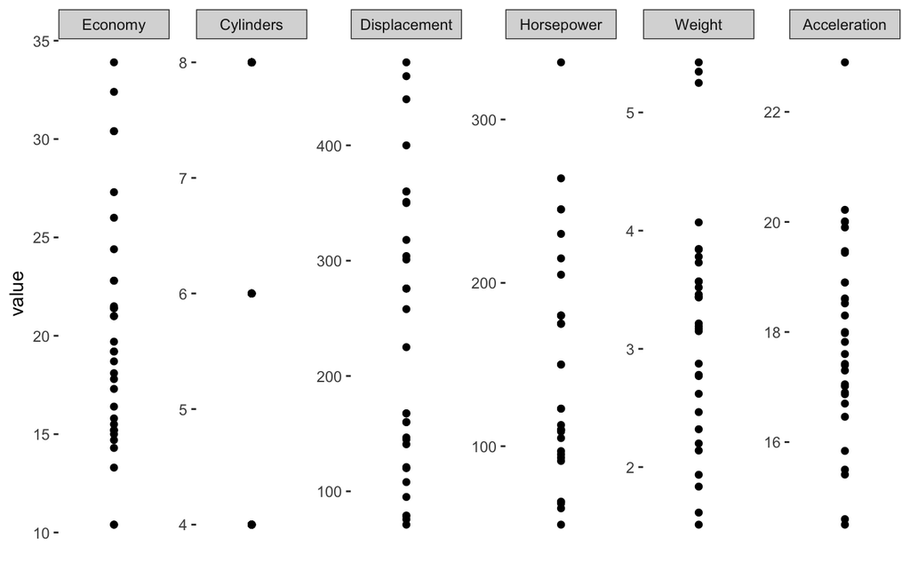

```r
data_faceting <- reshape2::melt(select(data, -Transmission), id.vars = c("Name"))
data_faceting$value <- as.numeric(data_faceting$value)
dotplot_facets <- ggplot(data_faceting, aes(x = 0, y = value)) + geom_point(show.legend = F) + theme(axis.ticks.x = element_blank(), axis.text.x = element_blank(), axis.title.x = element_blank()) + facet_wrap(~variable, scales = "free", nrow = 1)
dotplot_facets
```

Here, we can see in an instance that there is only three values for `Cylinders`, the outlier in `Horsepower` and `Acceleration`, etc. Obviously we can replace the dotplot with any of the one-dimensional visualisations discussed earlier and obtain a set of boxplots or violins:

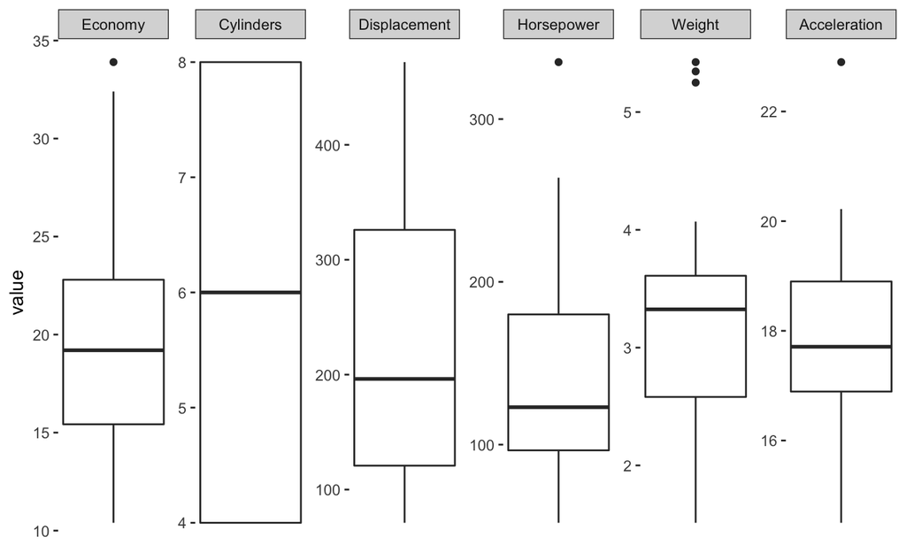

```r
boxplot_facets <- ggplot(data_faceting, aes(x = 0, y = value)) + geom_boxplot(show.legend = F) + theme(axis.ticks.x = element_blank(), axis.text.x = element_blank(), axis.title.x = element_blank()) + facet_wrap(~variable, scales = "free", nrow = 1)
boxplot_facets
```

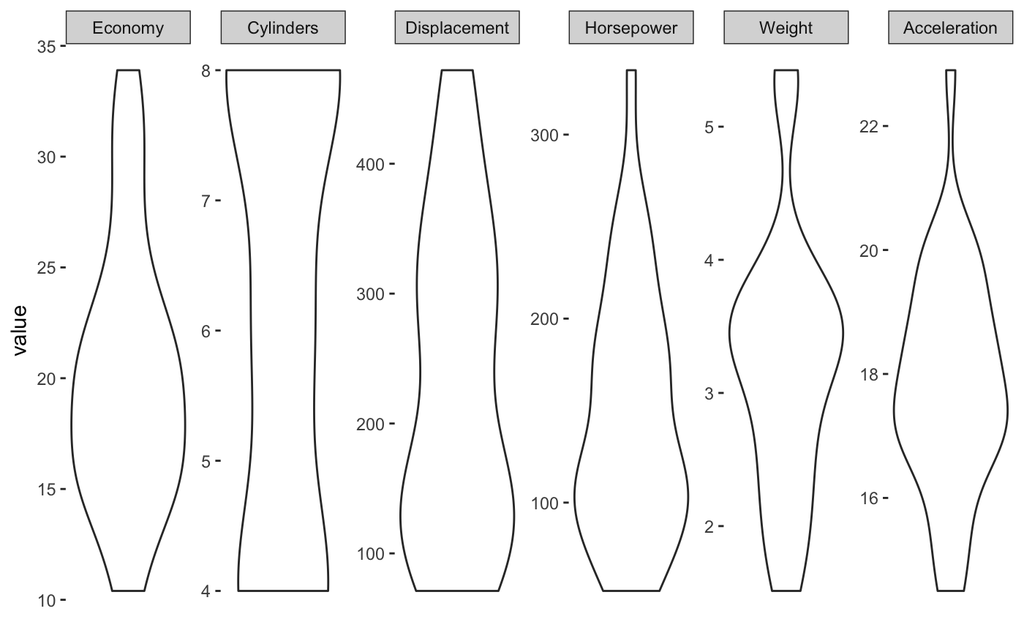

```r
violin_facets <- ggplot(data_faceting, aes(x = 0, y = value)) + geom_violin(show.legend = F) + theme(axis.ticks.x = element_blank(), axis.text.x = element_blank(), axis.title.x = element_blank()) + facet_wrap(~variable, scales = "free", nrow = 1)
violin_facets
```

Note that these visualisation corresponds a projection of our six-dimensional data to six one-dimensional representations, so we can’t see any relations between dimensions.

## Scatterplot Matrix (SPLOM)

The classical approach to inspect *all* pairwise relations between a set of variables is the scatterplotmatrix (SPLOM). Here, scatterplots are faceted into a symmetric matrix, where every row and column correspond to a single variable, and each cell is composed of a scatterplot of the corresponding variables. Since it is a symmetric matrix, the diagonal would normally show a dotplot of the variable and is often replaced with an explicit, line-based visualisation of the sample distribution. Similarly, only the lower or upper triangle of the matrix is typically used for scatterplots, because the other triangle would show mirrored versions of all scatterplots.

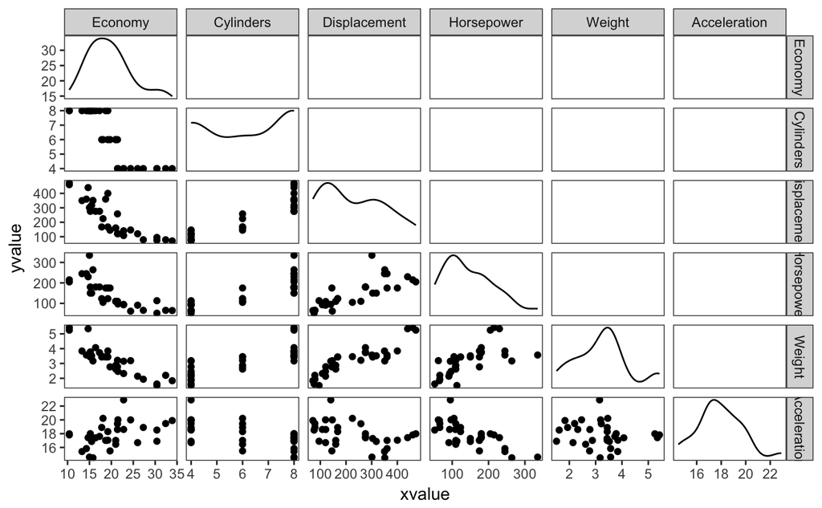

```r
splom <- GGally::scatmat(data) + theme_bw() + theme(panel.grid.major = element_blank(), panel.grid.minor = element_blank())
splom
```

Let’s store all the plots as pdf files on disk:

```r
ggsave(filename = "plots/dotplot.pdf", plot = dotplot, width = 4, height = 1, units = "in")
ggsave(filename = "plots/boxplot.pdf", plot = boxplot, width = 4, height = 1, units = "in")
ggsave(filename = "plots/bar_chart_transmission.pdf", plot = bar_chart_transmission, width = 4, height = 3, units = "in")
ggsave(filename = "plots/bar_chart_weight.pdf", plot = bar_chart_weight, width = 4, height = 3, units = "in")
ggsave(filename = "plots/stacked_bar_chart_economy.pdf", plot = stacked_bar_chart_economy, width = 4, height = 3, units = "in")
ggsave(filename = "plots/stacked_bar_chart_count.pdf", plot = stacked_bar_chart_count, width = 4, height = 3, units = "in")
ggsave(filename = "plots/normalized_stacked_bar_chart.pdf", plot = normalized_stacked_bar_chart, width = 4, height = 3, units = "in")
ggsave(filename = "plots/pie_chart_manual.pdf", plot = pie_chart_manual, width = 4, height = 3, units = "in")
ggsave(filename = "plots/pie_chart_automatic.pdf", plot = pie_chart_automatic, width = 4, height = 3, units = "in")
ggsave(filename = "plots/line_chart_transmission.pdf", plot = line_chart_transmission, width = 4, height = 3, units = "in")
ggsave(filename = "plots/line_chart_weight.pdf", plot = line_chart_weight, width = 4, height = 3, units = "in")
ggsave(filename = "plots/histogram_default.pdf", plot = histogram_default, width = 4, height = 3, units = "in")
ggsave(filename = "plots/histogram.pdf", plot = histogram, width = 4, height = 3, units = "in")
ggsave(filename = "plots/histogram_scaled.pdf", plot = histogram_scaled, width = 4, height = 3, units = "in")
ggsave(filename = "plots/histogram_density.pdf", plot = histogram_density, width = 4, height = 3, units = "in")
ggsave(filename = "plots/violin.pdf", plot = violin, width = 4, height = 3, units = "in")
ggsave(filename = "plots/scatterplot.pdf", plot = scatterplot, width = 4, height = 3, units = "in")
ggsave(filename = "plots/bubble.pdf", plot = bubble, width = 4, height = 3, units = "in")
ggsave(filename = "plots/bubble_size.pdf", plot = bubble_size, width = 4, height = 3, units = "in")
ggsave(filename = "plots/contour.pdf", plot = contour, width = 4, height = 3, units = "in")
ggsave(filename = "plots/dotplot_factes.pdf", plot = dotplot_facets, width = 10, height = 3, units = "in")
ggsave(filename = "plots/splom.pdf", plot = splom, width = 8, height = 6, units = "in")
ggsave(filename = "plots/boxplot_facets.pdf", plot = boxplot_facets, width = 10, height = 3, units = "in")
ggsave(filename = "plots/violin_facets.pdf", plot = violin_facets, width = 10, height = 3, units = "in")
```

[output not shown]